# Análisis de Logs de Servidor

Marcel Marimon, Maria Parera, Bernat Batle

2025-01-21

# 1. Carga de Datos

### Descompresión y carga del archivo CSV

```r
# Carga del archivo con separación por espacios y sin encabezados
data_path <- "epa-http.csv"
data <- read.csv(data_path, header = FALSE, sep = " ", quote = '"', stringsAsFactors = FALSE)

# Asignar nombres de columnas
data <- data %>% rename(
  ip = V1,
  timestamp = V2,
  request = V3,
  status = V4,
  bytes = V5
)

# Separar método, recurso y protocolo desde la columna 'request'
data <- data %>% separate(request, into = c("method", "resource", "protocol"), sep = " ")

# Visualización inicial
head(data)
```

```
##                        ip     timestamp method                     resource
## 1           141.243.1.172 [29:23:53:25]    GET               /Software.html
## 2 query2.lycos.cs.cmu.edu [29:23:53:36]    GET               /Consumer.html
## 3        tanuki.twics.com [29:23:53:53]    GET                   /News.html
## 4      wpbfl2-45.gate.net [29:23:54:15]    GET                            /
## 5      wpbfl2-45.gate.net [29:23:54:16]    GET /icons/circle_logo_small.gif
## 6      wpbfl2-45.gate.net [29:23:54:18]    GET      /logos/small_gopher.gif
##   protocol status bytes
## 1 HTTP/1.0    200  1497
## 2 HTTP/1.0    200  1325
## 3 HTTP/1.0    200  1014
## 4 HTTP/1.0    200  4889
## 5 HTTP/1.0    200  2624
## 6 HTTP/1.0    200   935
```

# 2. Descripción de los Datos

### Descripción

Los datos analizados corresponden a registros de un servidor Apache. Cada fila representa una interacción con el servidor, incluyendo:

- **Dirección IP:** Identificador único del usuario.
- **Fecha y hora:** Momento en que se realizó la petición.
- **Método HTTP:** Tipo de acción solicitada (GET, POST, etc.).
- **Recurso solicitado:** URL del recurso accedido.
- **Código de respuesta:** Estado de la petición (200, 404, etc.).
- **Bytes transferidos:** Tamaño de los datos enviados al cliente.

# 3. Limpieza de los Datos

```r
# Limpieza de columnas
data <- data %>% mutate(
  timestamp = str_replace_all(timestamp, "\\[|\\]", ""),
  timestamp = as.POSIXct(timestamp, format = "%d:%H:%M:%S"),
  bytes = as.numeric(bytes),
  status = as.integer(status)
)
# Verificar datos limpios
summary(data)
```

```
##       ip              timestamp                         method
##  Length:47748       Min.   :2025-01-29 23:53:25.00   Length:47748
##  Class :character   1st Qu.:2025-01-30 10:58:37.25   Class :character
##  Mode  :character   Median :2025-01-30 13:57:46.50   Mode  :character
##                     Mean   :2025-01-30 13:48:49.32
##                     3rd Qu.:2025-01-30 16:37:32.00
##                     Max.   :2025-01-30 23:53:07.00
##
##    resource           protocol             status          bytes
##  Length:47748       Length:47748       Min.   :200.0   Min.   :      0
##  Class :character   Class :character   1st Qu.:200.0   1st Qu.:    231
##  Mode  :character   Mode  :character   Median :200.0   Median :   1260
##                                        Mean   :227.1   Mean   :   7352
##                                        3rd Qu.:200.0   3rd Qu.:   3223
##                                        Max.   :501.0   Max.   :4816896
##                                                        NA's   :5331
```

# 4. Identificación de Usuarios

```r
# Usuarios únicos con errores y sin errores
users_with_errors <- data %>% filter(status >= 400) %>% distinct(ip)
users_without_errors <- data %>% filter(status < 400) %>% distinct(ip)

# Resultados
cat("Usuarios con errores:", nrow(users_with_errors), "\n")
```

```
## Usuarios con errores: 192
```

```r
cat("Usuarios sin errores:", nrow(users_without_errors), "\n")
```

```
## Usuarios sin errores: 2320
```

```r
# Tipos de errores y frecuencia
error_types <- data %>% filter(status >= 400) %>% count(status)
error_types
```

```
##   status   n
## 1    400   6
## 2    403 272
## 3    404 611
## 4    500  69
## 5    501 272
```

Identificamos usuarios con errores (192) y sin errores (2,320). Los códigos de error más frecuentes fueron 404 (no encontrado) y 403 (prohibido), lo que podría reflejar recursos inaccesibles o configuraciones restrictivas.

# 5. Análisis de Peticiones HTTP

```r
# Frecuencia de métodos HTTP
method_counts <- data %>% count(method)
method_counts
```

```
##   method     n
## 1    GET 46020
## 2   HEAD   106
## 3   POST  1622
```

```r
# Filtrar recursos tipo imagen
image_requests <- data %>% filter(str_detect(resource, "\\.(|img|jpg|jpeg|png|gif)$"))
head(image_requests)
```

```
##                   ip           timestamp method                     resource
## 1 wpbfl2-45.gate.net 2025-01-29 23:54:16    GET /icons/circle_logo_small.gif
## 2 wpbfl2-45.gate.net 2025-01-29 23:54:18    GET      /logos/small_gopher.gif
## 3     140.112.68.165 2025-01-29 23:54:19    GET           /logos/us-flag.gif
## 4 wpbfl2-45.gate.net 2025-01-29 23:54:19    GET         /logos/small_ftp.gif
## 5 wpbfl2-45.gate.net 2025-01-29 23:54:19    GET              /icons/book.gif
## 6 wpbfl2-45.gate.net 2025-01-29 23:54:19    GET           /logos/us-flag.gif
##   protocol status bytes
## 1 HTTP/1.0    200  2624
## 2 HTTP/1.0    200   935
## 3 HTTP/1.0    200  2788
## 4 HTTP/1.0    200   124
## 5 HTTP/1.0    200   156
## 6 HTTP/1.0    200  2788
```

```r
# Frecuencia de métodos en recursos tipo imagen
image_method_counts <- image_requests %>% count(method)
image_method_counts
```

```
##   method     n
## 1    GET 22163
## 2   HEAD    56
## 3   POST   206
```

### Gráfico 1: Distribución de los Métodos HTTP

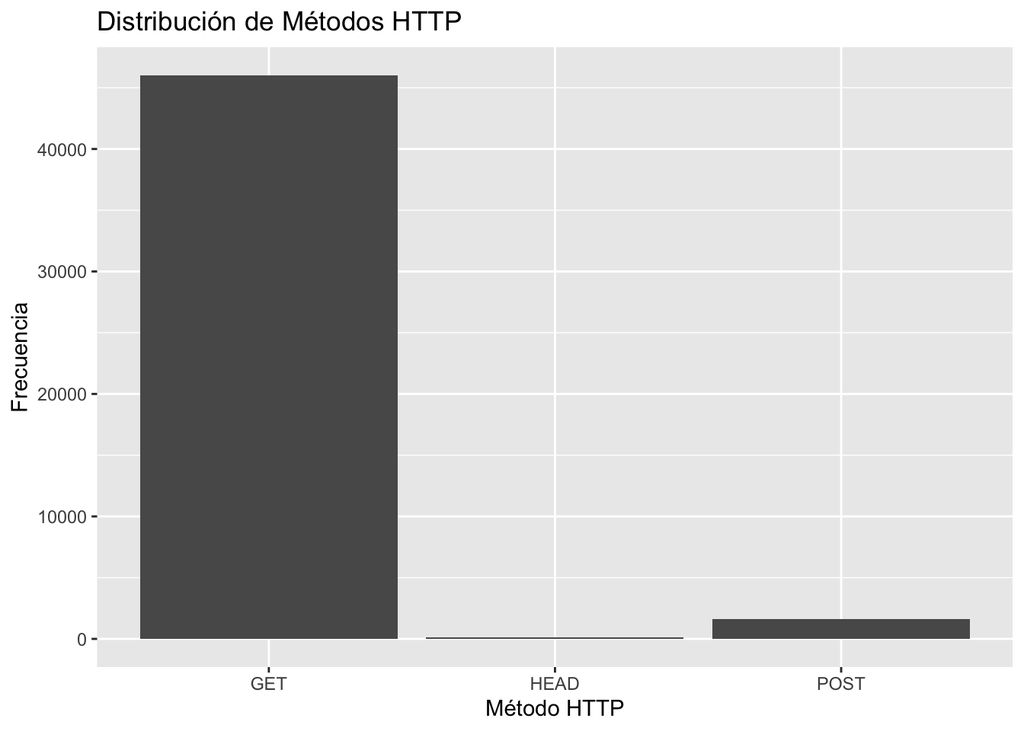

```r
ggplot(method_counts, aes(x = method, y = n)) +
  geom_bar(stat = "identity") +
  labs(title = "Distribución de Métodos HTTP", x = "Método HTTP", y = "Frecuencia")
```

### Gráfico 2: Usuarios con y sin errores

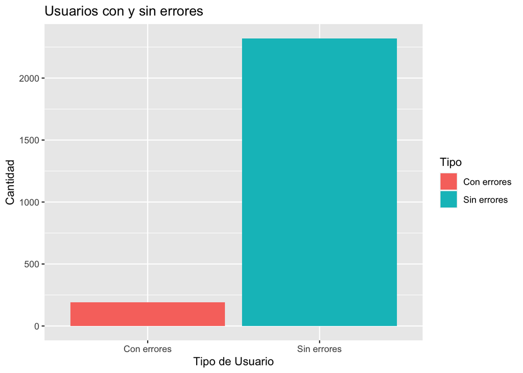

```r
users_data <- data.frame(
  Tipo = c("Con errores", "Sin errores"),
  Usuarios = c(nrow(users_with_errors), nrow(users_without_errors))
)

ggplot(users_data, aes(x = Tipo, y = Usuarios, fill = Tipo)) +
  geom_bar(stat = "identity") +
  labs(title = "Usuarios con y sin errores", x = "Tipo de Usuario", y = "Cantidad")
```

# 7. Peticiones a lo Largo del Tiempo

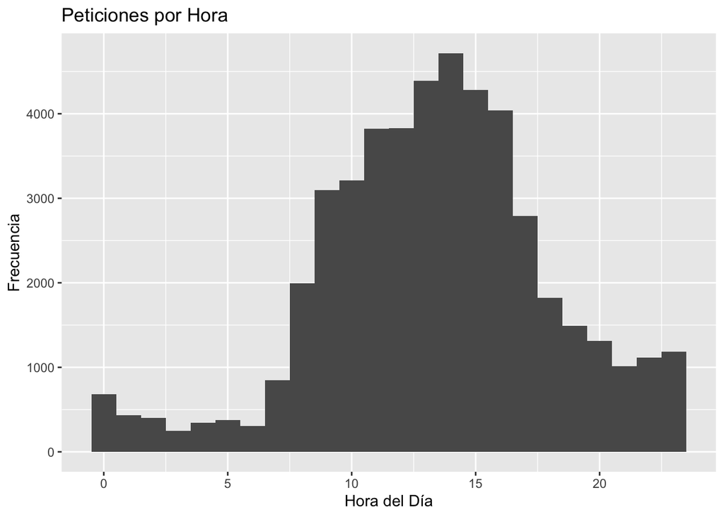

```r
data <- data %>% mutate(hour = format(timestamp, "%H"))

ggplot(data, aes(x = as.numeric(hour))) +
  geom_histogram(binwidth = 1) +
  labs(title = "Peticiones por Hora", x = "Hora del Día", y = "Frecuencia")
```

Las peticiones varían significativamente a lo largo del día, con picos en horas específicas. Esto sugiere un uso intensivo en ciertos momentos, relevante para ajustar la capacidad del servidor.

# 8. Análisis de Clústering

### Preparación de Datos para K-means

```r
data <- data %>% mutate(url_length = nchar(resource))

# Crear un DataFrame reducido con datos numéricos para clústering
numeric_data <- data %>% select(bytes, status, url_length) %>% na.omit()

# Asociar índices originales
numeric_data <- numeric_data %>% mutate(index = row_number())
```

### Ejecución del Clústering

```r
set.seed(123)
kmeans_3 <- kmeans(numeric_data %>% select(-index), centers = 3)
kmeans_6 <- kmeans(numeric_data %>% select(-index), centers = 6)

# Agregar los clusters al DataFrame original
data <- data %>% mutate(
  cluster_k3 = NA,
  cluster_k6 = NA
)
data$cluster_k3[numeric_data$index] <- kmeans_3$cluster
data$cluster_k6[numeric_data$index] <- kmeans_6$cluster
```

### Gráficos de Clústering

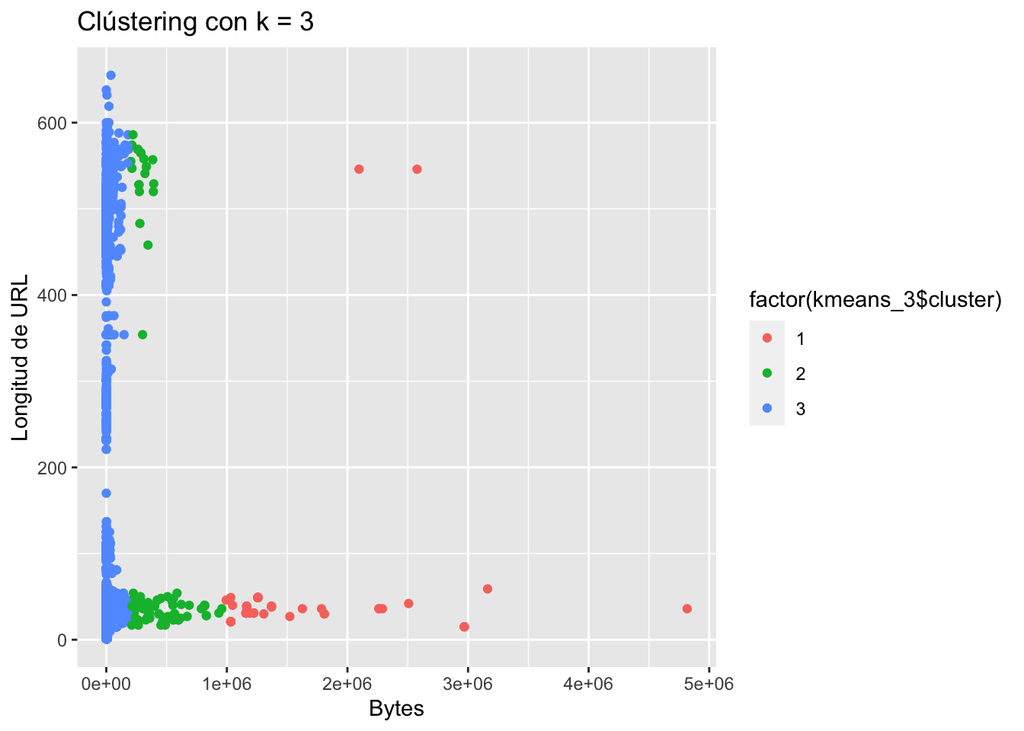

```r
ggplot(numeric_data, aes(x = bytes, y = url_length, color = factor(kmeans_3$cluster))) +
  geom_point() +
  labs(title = "Clústering con k = 3", x = "Bytes", y = "Longitud de URL")
```

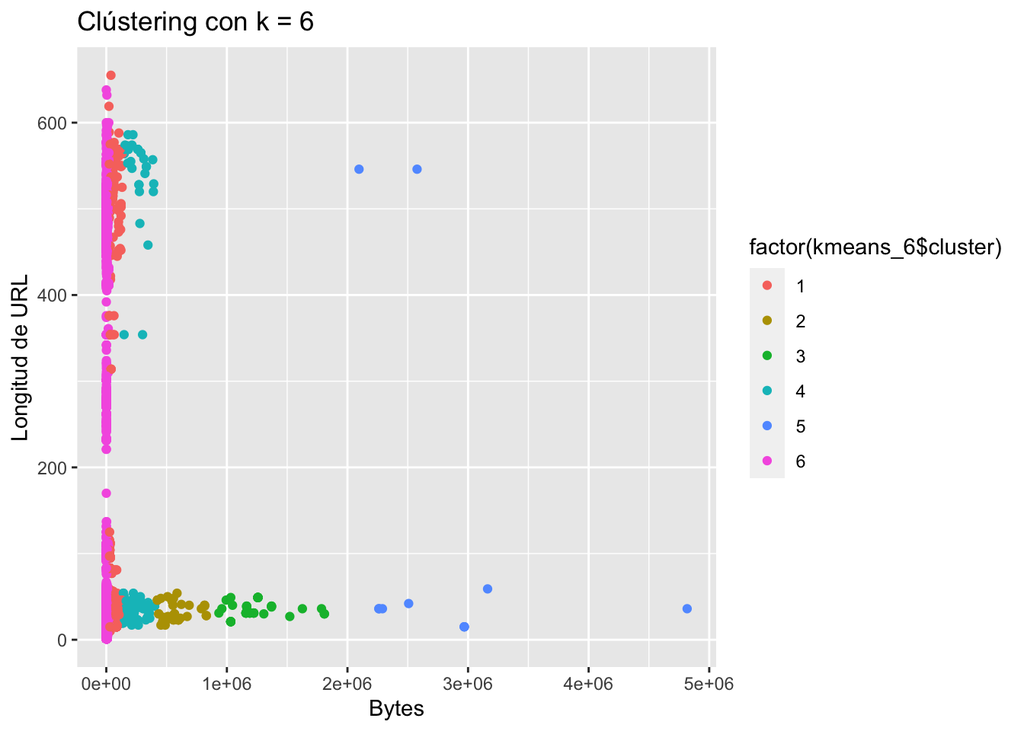

```r
ggplot(numeric_data, aes(x = bytes, y = url_length, color = factor(kmeans_6$cluster))) +
  geom_point() +
  labs(title = "Clústering con k = 6", x = "Bytes", y = "Longitud de URL")
```

El clústering con k=3 identifica patrones generales en los datos, dividiendo los registros en clústeres bien diferenciados que capturan accesos comunes, peticiones grandes y casos intermedios. En cambio, k=6 proporciona una segmentación más detallada, separando subgrupos dentro de los registros dominantes pero introduciendo cierta dispersión en los datos. Aunque k=6 puede capturar más matices,k=3 ofrece una visión más manejable y consistente para interpretar el comportamiento de los usuarios. La decisión final depende del propósito analítico, pero k=3 parece más eficiente para describir los patrones principales.